# 10_1_Numpy-Clase slides

### 6.2.1 rand

Crea un array de la forma dada y la rellena con muestras aleatorias de una distribución uniforme sobre [0, 1).

**Algunos tipos de Distribuciones**

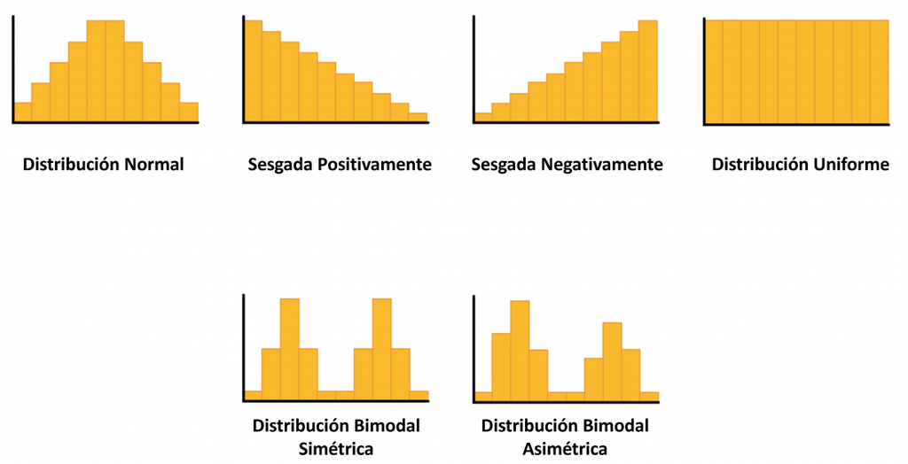

```python
# creacion de un array de 2 elementos 1 una dimension
np.random.rand(2) #Los numeros aleatorios seran de una distribucion uniforme
```

```python
# creacion de una matriz de 5x5
np.random.rand(5,5) #Los numeros aleatorios seran de una distribucion uniforme
```

**Vamos a hacer una pequeña comprobación para ver que la distribución efectivamente es uniforme**

```python
import matplotlib.pyplot as plt #utilizamos matplotlib para graficar, lo veremos con más detalle en capitulos posteriores.

#nos permite insertar gráficos dentro del notebook.
%matplotlib inline
```

```python
x = np.random.rand(100)#genera 100 valores aleatorios con distribución uniforme
```

```python
plt.hist(x)
plt.show()
```

[output not shown]

### 6.2.2 randn

**Devuelve una muestra (o muestras) de la distribución “estándar normal”.** A diferencia del rand que es uniforme. Genera valores aleatorios entre -4 y 4 pero la mayoria de estos se concentran entre -1 y 1.

Nota: acordaros de la n final de randn para saber que es de nomal (distribución normal)

```python
# creacion de un array de 2 elementos 1 una dimension
np.random.randn(2) #Los numeros aleatorios seran de una distribucion "estándar normal"
```

**¿Comprobamos si efectivamente los números aleatorios generados tienen una distribución normal?**

```python
x = np.random.randn(1000000)#genera 1 millon de valores con distribución normal
plt.hist(x)
plt.show()
```

[output not shown]

### 6.2.3 randint

Entrega numeros enteros aleatorios desde inicio (inclusivo) hasta final (exclusivo).

```python
np.random.randint(1,100) # Genera un numero aleatorio entre 1 y 99
```

```python
np.random.randint(1,100,(10,2)) # Genera una matriz de 10x2 elementos con valores aleatorios entre 1 y 99
```

### EJERCICIOS

### Ejercicio 6.2.1

Programa que muestre un array de 15 valores aleatorios que signa una distribución normal.

#### Solución

### Ejercicio 6.2.2

Escribe una matriz de 3x3x3 con valores aleatorios.

#### Solución

### Ejercicio 6.2.3

Crea un array de todos los enteros pares del 30 al 70.

### 7. Métodos para Añadir, Eliminar y Ordenar

### 7.1 Añadir Elementos Al Final- Append(...)

Método que ofrece Numpy para agregar elementos al final de un array. Tiene la siguiente forma:

**np.append(arr, values, axis=None)**

- arr: es un array de Numpy.
- values: son los valores que se agregan al final del array que se pasa en el parámetro anterior. Este elemento puede ser también un array de Numpy.
- axis: es el **eje opcional en el que se agregan los valores.**

Importante

El método no modifica el array original, sino que crea una copia a la que le agrega los nuevos valores.

```python
arr = np.array([1, 2, 3, 4, 5])
b = np.append(arr, 10)
print(f"Array Original: {arr}")
print(f"Array Modificado: {b}")
```

**Tambien podemos agregar otro Array**

```python
arr = np.array([1, 2, 3, 4, 5])
arrb = np.array([10,11])
np.append(arr,arrb)
```

**Axis**

Si no se indica un valor para axis y arr es una matriz, el objeto **se aplanará antes de agregar los nuevos elementos.** Siendo las posibles opciones de este parámetro:

- 0: los valores se agregarán en el eje 0, es decir, **axis = 0 agregará nuevas filas.**
- 1: los valores se agregarán en el eje 1, es decir, **axis = 1 agregará nuevas columnas.**

**Agregar elementos al final en Arrays 2D o matrices**

Además de con arrays 1D el método **np.append() también se puede emplear en matrices.** Como hemos comentado anteriormente es necesario indicar mediante el **parámetro axis si los nuevos elementos se agregan por filas o columnas.**

En el caso de que no se indique el parámetro la matriz se aplanara antes de agregar los elementos, obteniéndose como resultado un array. Esto es lo que vamos a ver en el siguiente ejemplo:

```python
#vamos a probar lo que acabamos de comentar. Creamos una matriz y agregamos una lista de valores sin indicar axis
matriz = np.array([
                    [1,2,3],
                    [4,5,6],
                    [7,8,9]
                ])
print(matriz)

matrizb = np.append(matriz, [10,11,12])#no indicamos nada y aplana la matriz.
print(matrizb)
```

**Vamos a agregar una nueva fila**

```python
#ahora vamos a indicarle donde queremos añadir. axis= 0 para agregar una nueva fila
matrizc = np.append(matriz, [[10,11,12]], axis=0)#axis0
print(matrizc)
```

**Ahora vamos a agregar una nueva columna (axis=1)**

```python
matrizd = np.append(matriz, [[10],[11],[12]], axis=1)#axis1
print(matrizd)
```

### 7.2 Insertar elemento en una Posición en Concreto - Insert(...)

Podemos insertar nuevos elementos en una posición en concreto de un Array. La forma de hacerlo es la siguiente:

**np.insert(arr, obj, values, axis=None)**

Siendo arr el array donde insertar los nuevos valores

obj la posicion a partir de la cual insertar

values los valores

axis el eje que se va a tener en cuenta para insertar. Por defecto viene a None.

**Returns:** Devuelve un nuevo array copia de arr con los valores insertados

```python
a = np.array([[1, 1], [2, 2], [3, 3]])
a
```

```python
#insertamos en la posición 1 el elemento 5. Como no indicamos eje, aplana el Array 2D e inserta en la pos 1
np.insert(a, 1, 5)
```

Utilicemos ahora axis para insertar en la matriz

```python
np.insert(a, 1, 5, axis=1)
```

Si quisiera añadir una columna que no tuviera el mismo valor en cada posición, lo haría así:

```python
b = np.insert(a, [1], [[1],[2],[3]], axis=1)
b
```

Vamos a insertar ahora varios elementos a partir de una posición

```python
c = np.array([1, 5, 1, 2, 2, 3, 3])
c
```

```python
np.insert(c, [0], [8, 6])
```

### 7.3 concatenate(...)

Podemos usar el método concatenate para concatenar vectores y matrices

```python
#si tenemos los arrays 1D
a = np.array([1, 2, 3, 4])
b = np.array([5, 6, 7, 8])

#Podemos concatenarlos con:
np.concatenate((a, b))
```

O si tenemos estas matrices:

```python
x = np.array([[1, 2], [3, 4]]) #matriz 2x2 (2 filas x 2 columnas)
y = np.array([[5, 6]])#matriz 1x2 (1 fila x 2 columnas)

#podemos concatenarlas con:
np.concatenate((x, y), axis=0)
```

### 7.4 Eliminar elementos - Delete(...)

El método acepta tres parámetros:arr, obj y axis y devuelve un array NumPy.

- Arr es el **array NumPy de la que deseamos eliminar elementos.**
- Obj es una **lista de números enteros con los índices de los elementos que deben eliminarse del array.**
- Axis es un argumento opcional. Se refiere al **eje a lo largo del cual los elementos seleccionados por el obj deben eliminarse.**
  - Si se asigna un valor None a este parámetro, arr se aplana y se lleva a cabo la eliminación en esta matriz aplanada.

```python
a = np.array([1, 2, 3, 4, 5, 6, 7, 8, 9, 10])
indices = [3, 5, 7]#posiciones del indice que quiero borrar
#ahora le paso al método delete los indices a borrar
```

```python
print(matriz)#para ver sobre lo que vamos a trabajar
#borra los indices 1 y 2 del eje 0.
#muestra la matriz antes y despues del borrado
```

```python
#vamos a eliminar ahora columnas. Dada la siguiente matriz, elimina las columnas 1 y 2
mimatriz = np.array([[1, 2, 3, 4, 5], [11, 12, 13, 14, 15], [21, 22, 23, 24, 25]])
print(mimatriz)

#añade el código aquí
```

**Elimina ahora los elementos 1 y 2 sin indicar el parámetro axis.**

¿Qué valores ha eliminado?

### 7.4.1 Eliminar Duplicados

Dado el siguiente Array 2D. Averigua dos formas de eliminar los duplicados

data = np.array([10,10,20,20,30,30 ]

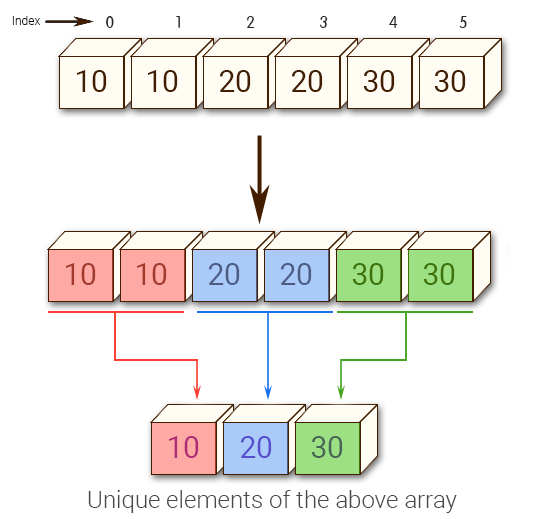

```python
data = np.array([[1,8,3,3,4],
                 [1,8,9,9,4],
                 [1,8,3,3,4]])
```

### 7.4 Ordenar elementos - Sort(...)

Método que devuelve una copia ordenada del Array.

Forma de usarlo:

**np.sort(a, axis=-1, order=None)**

- a - Es el array a ordenar
- axis - eje que se debe tener en cuenta para ordenar el array. Es opcional. Si no se pone nada, el array ordena por el último eje, si se le indica None, se aplana y luego se ordena.
- order: parámetro opcional, para indicarle el campo por el que queremos ordenar.

**Vamos a ver algunos ejemplos de como funciona este método.**

```python
a = np.array([[1,4],[3,1]])
a
```

```python
np.sort(a)#ordena por axis=1(ultimo eje)
```

```python
np.sort(a, axis=0)#ordena por el primer eje
```

```python
np.sort(a, axis=None)
```

Vamos a ver ahora un ejemplo en el que le indiquemos por qué campo ordenar.

```python
data_type = [('nombre', 'U30'), ('clase', int), ('altura', float)]
detalles_estudiantes = [('Jaime Pinillo', 5, 178.5), ('Macarena', 6, 172.5),('Pablo Escobar', 5, 172.5), ('Pit Samptras', 5, 185.1)]
# creamos la estructura array de estudiantes
estudiantes = np.array(detalles_estudiantes, dtype=data_type)
print("Array original:")
print(estudiantes)
print("Ordenado por altura")

print(np.sort(estudiantes, order='altura')) #puedo ordenar por varios criterios?
```